# CARRA Analysis

Abhijit Dasgupta, PhD

October 05, 2020 11:10 PM

**Data version:** The version of data we’re using is from 2020-01-31 15:45.

# Principle 1 : 20% to 75% of children with SLE will develop nephritis

From the data dictionary, this question is answered in the variable SLICC00

I have verified that this definition is compatible with the raw data when we use both WHO and ISNRPS criteria.

Note: Subject has lupus nephritis if any of WHO 2-6 or ISNRPS 2-6 are positive

```r
slicc_info <- vroom(here('data/raw/slicc_data_2020-01-31_1545.csv'),
                    col_select = c(subjectId, visit = folderName,
                                   SLICC00)) %>%
  clean_names()
raw_biopsy <- readRDS(here('data/rda/biopsy_classes1.rds')) # see biopsy_classes.R
total_ln <- raw_biopsy %>%
  group_by(subject_id) %>%
  summarize(LN = ifelse(any(LN==1, na.rm=T), 1, 0)) %>%
  ungroup()

total_ln %>%
  mutate(LN = ifelse(LN==1, 'Positive','Negative')) %>%
  tabyl(LN) %>%
  adorn_pct_formatting() %>%
  set_names(c('Lupus nephritis','N','Percent')) %>%
  kable(caption = 'Frequency of lupus nephritis') %>%
  kable_styling(full_width = F)
```

Frequency of lupus nephritis

| Lupus nephritis | N | Percent |
| --- | --- | --- |
| Negative | 459 | 68.0% |
| Positive | 216 | 32.0% |

# Principle 2: 82% of LN in cSLE develops within the first year of diagnosis and 92% within 2 years

We are going to look at actual date of SLE diagnosis and the date of biopsy. We’ll restrict to individuals with LN. We’ll also assume that biopsy dates prior to date of lupus diagnosis are aberrant and should be considered the same time as the diagnosis date.

A limitation of this analysis is that we only have year of diagnosis and year of biopsy, not the actual dates for identifiability reasons. So the differences in calendar years may represent periods longer than a year, depending on when the actual dates of the diagnosis and biopsy were.

```r
pdis <- vroom(here('data/raw/pdisease_data_2020-01-31_1545.csv')) %>%
  clean_names() %>%
  select(subject_id, dxdt_yyyy) %>%
  group_by(subject_id) %>%
  summarize(dxdt = min(dxdt_yyyy, na.rm=T)) %>%
  ungroup()
raw_biopsy <- readRDS(here('data/rda/biopsy_classes1.rds')) %>%
  select(subject_id, visit, event_index, biopdtc_yyyy, biopsdtc_yyyy, LN) %>%
  filter(LN==1) %>%
  group_by(subject_id) %>%
  summarize(biopdtc = min(biopdtc_yyyy, na.rm=T), biopsdtc = min(biopsdtc_yyyy, na.rm=T),
            LN = ifelse(any(LN==1, na.rm=T), 1,0)) %>%
  ungroup()
biopsy <- all_subjects %>% select(subject_id) %>% distinct() %>% left_join(raw_biopsy) %>% left_join(pdis) %>%
  mutate(time_to_pos_biopsy = biopsdtc - dxdt)

# LN_pos <-  LN_ISNRPS %>% full_join(LN_WHO) %>%
#   mutate(LN_pos = ISNRPS_pos | WHO_pos) %>%
#   select(-ISNRPS_pos, -WHO_pos) %>%
#   mutate(folderName = as.factor(folderName)) %>%
#   mutate(folderName = fct_relevel(folderName, 'Baseline','3 month','6 month',
#                                   '12 month','18 month','24 month','30 month','36 month'))
# LN_pos %>%
#   count(folderName, LN_pos) %>%
#   spread(LN_pos, n) %>%
#   rename('pos' = `TRUE`, 'neg' = `FALSE`) %>%
#   mutate(pos_perc = pos / (pos + neg)*100) %>%
#   mutate(cum_pos = cumsum(ifelse(is.na(pos), 0, pos)),
#          cum_neg = cumsum(ifelse(is.na(neg), 0, neg))) %>%
#   mutate(cum_perc = cum_pos/(cum_pos+cum_neg)*100) %>%
#   rename('visit'='folderName') %>%
#   select(visit, neg, pos, pos_perc, cum_perc) %>%
#   kable() %>%
#   kable_styling()
biopsy %>%
  filter(LN==1) %>%
  mutate(time_to_pos_biopsy = ifelse(time_to_pos_biopsy==-1, 0,
                                     time_to_pos_biopsy)) %>%
  mutate(time_to_pos_biopsy = factor(time_to_pos_biopsy),
         time_to_pos_biopsy = fct_other(time_to_pos_biopsy,
                                        keep = as.character(-1:2),
                                        other_level = '3+')) %>%
  tabyl(time_to_pos_biopsy) %>%
  mutate(`Cumulative percent` = cumsum(percent)) %>%
  rename('Years' = time_to_pos_biopsy) %>%
  adorn_pct_formatting() %>%
  adorn_totals() %>%
  mutate(across(3:4, ~str_remove(.x, '-'))) %>%
  kable(caption = 'Time from diagnosis to positive biopsy') %>%
  kable_styling(full_width=FALSE)
```

Time from diagnosis to positive biopsy

| Years | n | percent | Cumulative percent |
| --- | --- | --- | --- |
| 0 | 158 | 73.1% | 73.1% |
| 1 | 29 | 13.4% | 86.6% |
| 2 | 10 | 4.6% | 91.2% |
| 3+ | 19 | 8.8% | 100.0% |
| Total | 216 |  |  |

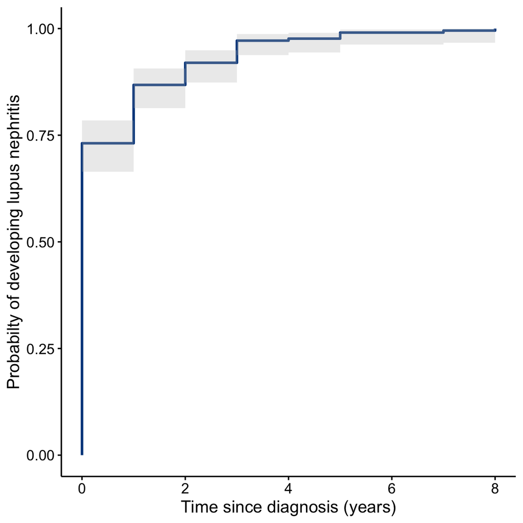

```r
visits <- vroom(here('data/raw/vis_data_2020-01-31_1545.csv'),
                col_select = c('subjectId','startDate','folderName','VISITDTC_YYYY'),
                .name_repair = 'universal') %>%
  clean_names()
timelines <- visits %>%
  group_by(subject_id) %>%
  summarize(start_date = unique(start_date), end_date = max(visitdtc_yyyy, na.rm=T))
timelines <- timelines %>%
  left_join(biopsy %>% select(subject_id, biopsdtc, LN, dxdt)) %>%
  mutate(last_date = pmin(end_date, biopsdtc, na.rm=T),
         LN = ifelse(is.na(LN), 0, LN)) %>%
  mutate(time_to_LN = last_date - dxdt) %>%
  filter(time_to_LN >= 0)


s2 <- survival::survfit(survival::Surv(time_to_LN, LN)~1,
                        data=timelines %>% filter(LN==1))
survminer::ggsurvplot(s2, risk.table = FALSE, conf.int = TRUE,
                      fun = 'event',
                      palette = 'lancet',
                      legend='none',
                      xlab='Time since diagnosis (years)',
                      ylab = "Probabilty of developing lupus nephritis")
```

The following also shows the Kaplan-Meier curve for all subjects, with regard to LN incidence.

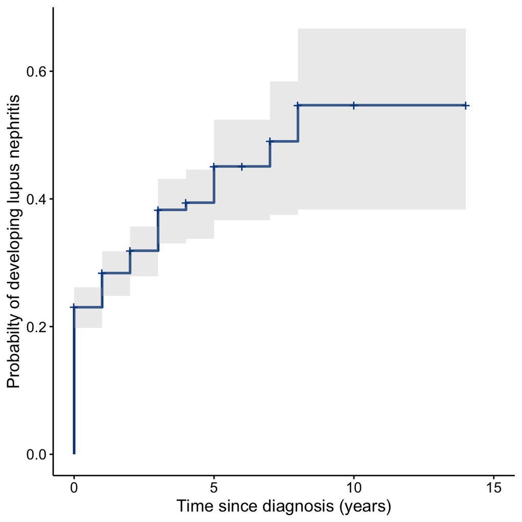

```r
s1 <- survival::survfit(survival::Surv(time_to_LN, LN)~1, data=timelines)
survminer::ggsurvplot(s1, risk.table = FALSE, conf.int = TRUE,
                      fun = 'event',
                      palette = 'lancet',
                      legend='none',
                      xlab='Time since diagnosis (years)',
                      ylab = "Probabilty of developing lupus nephritis")
```

> In this analysis there were 4 individuals who had a negative time between diagnosis and LN biopsy. I changed that time to 0, assuming that we’re dealing with rounding error

```r
# Principle 3 -------------------------------------------------------------
```

# Principle 3: Membranous (class V) LN more often presents with nephrotic syndrome than proliferative LN (class III or IV)

Definition of LN classes:

1. Class III = WHO-3 or ISNRPS-3
2. Class IV = WHO-4 or ISNRPS-4
3. Class V = WHO-5 or ISNRPS-5

Based on conversations (5/8/2020), we will create 3 mutually exclusive classes for LN for this analysis. These are

1. Class III/IV only
2. Class III/IV + V
3. Class V only

```r
# This has been modified in biopsy_classes.R and in now included in the
# raw_biopsy dataset
```

The definition of nephrotic syndrome is as follows:

1. The presence of nephrotic range proteinuria, which is a urine protein:creatinine ratio > 1mg/mg or if there is a 24 hour urine instead of a urine protein:creatinine ratio (different docs check it differently), it would be a 24 hour protein excretion greater than 3.5 g/24 hours.
2. Hypoalbuminemia (an albumin less than 3 g/dL)
3. On examination, documentation of edema

### Poor availability of data

To evaluate this principle we need information on protein:creatinine ratios in urine, albumin levels and documentation of edema. First of all, it does not appear that **albumin was collected**, at least it is not available in the CARRA database.

Second, there is a serious lack of urine protein:creatinine ratios. See the separate report, which highlights the fact that only around 25-30% of subjects had urine protein:creatinine ratios available at any visit.

These two issues preclude us from looking at nephrotic syndrome as an outcome for any analysis.

### UPC analysis based on available data

> In the following analysis, we took data from the first visit where LN was confirmed, which may be the baseline visit.

> There were 8 individuals who had different results in 2 biopsies; they were III/IV only in one and V only in another. I have placed them in the III/IV + V category

```r
urine <- vroom(here('data/raw/urine_data_2020-01-31_1545.csv'))
urine <- urine %>%
  select(subjectId, visit = folderName, DIPSTICK, PROT30, URINRATO, RATIOUNT, SPOTURIN) %>%
  clean_names()

raw_biopsy <- readRDS(here('data/rda/biopsy_classes1.rds')) %>%
  select(subject_id, visit, LN, LN3, LN4, LN5, LN34, LN345, LN50)
LN_subjects <- raw_biopsy %>%
  group_by(subject_id) %>%
  summarize(LN_ind = any(LN==1, na.rm=T)) %>%
  filter(LN_ind)
LN_classes <- raw_biopsy %>%
  group_by(subject_id) %>%
  summarise_at(vars(starts_with("LN")),
               ~ifelse(any(. == 1), 1, 0)) %>%
  ungroup()
# There are edge cases where multiple biopsies have led to different
# LN classes. I'm taking the "any" approach in that the person's final
# class is based on all biopsies and any classes resulting from those
# biopsies
LN_classes <- LN_classes %>%
  filter(!is.na(LN)) %>%
  mutate(
    LN34 = ifelse((LN3==1 | LN4==1) & (LN5==0), 1, 0),
    LN345 = ifelse((LN3==1 & LN5==1) | (LN4==1 & LN5==1), 1, 0),
    LN50 = ifelse(LN5==1 & LN3==0 & LN4==0, 1, 0)
  )
saveRDS(LN_classes, here('data/rda/LN_classes1.rds'), compress=T)


d <- urine %>% select(subject_id, visit, urinrato, ratiount, spoturin) %>%
  right_join(LN_classes) %>% semi_join(LN_subjects) %>%
  mutate(spoturin = ifelse(spoturin=='Not Done', NA, spoturin))

d <- d %>%
  mutate(visit1 = as.character(visit)) %>%
  mutate(visit1 = ifelse(visit1 == 'Baseline', 'Baseline0', visit1)) %>%
  mutate(visit1 = ifelse(visit1 == 'Unsch', 'Unsch100', visit1)) %>%
  mutate(visit_no = parse_number(visit1)) %>%
  # mutate(visit_no = as.numeric(str_remove(visit, ' month'))) %>%
  # mutate(visit_no = ifelse(visit=='Baseline', 0, visit_no),
         # visit_no = ifelse(visit=='Unsch', 100, visit_no)) %>%
  mutate(visit = fct_reorder(visit, visit_no))

d1 <- d %>% filter(LN==1) %>%
  group_by(subject_id) %>%
  filter(visit_no == min(visit_no)) %>%
  mutate(across(LN34:LN50, ~ifelse(any(.x==1),1,0))) %>%
  ungroup() %>%
  distinct() %>%
  mutate(LN345 = ifelse(LN34==1 & LN50==1, 1, LN345),
         LN34 = ifelse(LN345==1, 0, LN34),
         LN50 = ifelse(LN345==1, 0, LN50),
         Other = ifelse(LN34==0 & LN345==0 & LN50==0, 1, 0))

d2 <- d1 %>%
  pivot_longer(
    cols = c(LN34:LN50, Other),
    names_to = 'LN_class',
    values_to = 'indic') %>%
  filter(indic==1)
```

#### Discrete UPC outcome

```r
d2 %>%
  mutate(LN_class = factor(LN_class),
         LN_class = fct_recode(LN_class,
                               'Class III/IV only'='LN34',
                               'Class III/IV + V'='LN345' ,
                               'Class V only'='LN50' )) %>%
  rename('UPC in last 30 days' = spoturin) %>%
  table1::table1(~`UPC in last 30 days` | LN_class, data=.)
```

|  | Class III/IV only (N=140) | Class III/IV + V (N=22) | Class V only (N=30) | Other (N=24) | Overall (N=216) |
| --- | --- | --- | --- | --- | --- |
| UPC in last 30 days |  |  |  |  |  |
| < 0.5 mg/mg | 32 (22.9%) | 2 (9.1%) | 6 (20.0%) | 7 (29.2%) | 47 (21.8%) |
| > = 0.5 mg/mg | 35 (25.0%) | 8 (36.4%) | 9 (30.0%) | 3 (12.5%) | 55 (25.5%) |
| Missing | 73 (52.1%) | 12 (54.5%) | 15 (50.0%) | 14 (58.3%) | 114 (52.8%) |

##### Testing

If we take only the available data, we can do a bit of statistical testing.

```r
out2 <- tabyl(d2 %>%
                rename('LN class' = 'LN_class',
                       'UPC in last 30 days' = spoturin)
              , `LN class`, `UPC in last 30 days`, show_na=FALSE)
out2 %>%
  adorn_percentages() %>%
  adorn_totals('col') %>%
  adorn_pct_formatting() %>%
  adorn_ns() %>%
  mutate(`LN class` = factor(`LN class`),
         `LN class` = fct_recode(`LN class`,
                                 'Class III/IV only'='LN34',
                                 'Class III/IV + V'='LN345' ,
                                 'Class V only'='LN50' )) %>%
  mutate(Test = c("Fisher's test",
                  paste('P-value =',round(fisher.test(out2)$p.value,2)),
                  '','')) %>%
  adorn_title() %>%
  kable(caption = 'Frequency distribution of UPC (discrete) by LN class using available data') %>%
  row_spec(1, bold=TRUE) %>%
  kable_styling()
```

Frequency distribution of UPC (discrete) by LN class using available data

|  | UPC in last 30 days |  |  |  |
| --- | --- | --- | --- | --- |
| LN class | < 0.5 mg/mg | > = 0.5 mg/mg | Total | Test |
| Class III/IV only | 47.8% (32) | 52.2% (35) | 100.0% (67) | Fisher’s test |
| Class III/IV + V | 20.0% (2) | 80.0% (8) | 100.0% (10) | P-value = 0.16 |
| Class V only | 40.0% (6) | 60.0% (9) | 100.0% (15) |  |
| Other | 70.0% (7) | 30.0% (3) | 100.0% (10) |  |

#### Continuous UPC outcome

```r
d2 %>%
  mutate(LN_class = factor(LN_class),
         LN_class = fct_recode(LN_class,
                               'Class III/IV only'='LN34',
                               'Class III/IV + V'='LN345' ,
                               'Class V only'='LN50' )) %>%
  rename('LN class' = 'LN_class',
         'UPC ratio' = urinrato) %>%
  table1::table1(~`UPC ratio` | `LN class`, data=.)
```

|  | Class III/IV only (N=140) | Class III/IV + V (N=22) | Class V only (N=30) | Other (N=24) | Overall (N=216) |
| --- | --- | --- | --- | --- | --- |
| UPC ratio |  |  |  |  |  |
| Mean (SD) | 79.2 (365) | 13.6 (21.4) | 2.96 (2.21) | 156 (208) | 64.7 (296) |
| Median [Min, Max] | 1.20 [0.0500, 2210] | 4.15 [0.350, 60.0] | 3.46 [0.0500, 5.99] | 56.0 [0.220, 484] | 1.70 [0.0500, 2210] |
| Missing | 101 (72.1%) | 14 (63.6%) | 20 (66.7%) | 19 (79.2%) | 154 (71.3%) |

```r
d2_anova = d2 %>% filter(LN_class != 'Other') %>%
  rename('LN class' = LN_class) %>%
  lm(urinrato ~ `LN class`, data=.) %>% broom::glance()
```

We can also perform an ANOVA analysis using available data to see whether there are any differences in UPC ratio betwen the LN classes III/IV, III/IV + V, and V only. This gives a p-value of 0.71.

### Frequency distribution of LN classes

As a descriptive analysis, we present the frequency distribution of LN classes in this dataset

```r
# raw_biopsy <- readRDS(here('data/rda/biopsy_classes1.rds'))
# LN_classes <- raw_biopsy %>%
  # group_by(subject_id) %>%
  # summarise_at(vars(starts_with("LN")),
               # ~ifelse(any(. == 1), 1, 0)) %>%
  # ungroup()

LN_classes <- read_rds(here('data/rda/LN_classes1.rds'))

LN_classes %>% mutate(LN=ifelse(LN==0, 'No', 'Yes')) %>%
  tabyl(LN) %>%
  adorn_totals() %>%
  adorn_pct_formatting() %>%
  kable(caption = 'Lupus nephritis frequency') %>%
  kable_styling()
```

Lupus nephritis frequency

| LN | n | percent |
| --- | --- | --- |
| No | 459 | 68.0% |
| Yes | 216 | 32.0% |
| Total | 675 | 100.0% |

```r
LN_classes %>%
  select(LN34:LN50) %>%
  rename(`III/IV` = LN34,
         `III/IV + V` = LN345,
         `V only` = LN50) %>%
  pivot_longer(cols = everything(), names_to='LN Class', values_to = 'Indicator') %>%
  filter(Indicator==1) %>%
  tabyl(`LN Class`) %>%
  adorn_totals() %>%
  adorn_pct_formatting() %>%
  kable(caption = 'Frequency distribution of LN classes') %>%
  kable_styling()
```

Frequency distribution of LN classes

| LN Class | n | percent |
| --- | --- | --- |
| III/IV | 140 | 72.9% |
| III/IV + V | 22 | 11.5% |
| V only | 30 | 15.6% |
| Total | 192 | 100.0% |

# Principle 4: Short term renal outcomes are worse in blacks

```r
# Principle 4 -------------------------------------------------------------
```

Based on conversations, we will consider only LN patients and take their first visit with confirmed LN as the baseline time for the GFR change analysis. We will look at race, baseline GFR level, as well as LN classes, as stratifying variables

```r
all_subjects <- readRDS(here('data/rda/all_subjects.rds'))
demographic <- readRDS(here('data/rda/demographic.rds')) # computed below
short_outcomes <- readRDS(here('data/rda/short_outcomes.rds')) %>%
  mutate(visit = as.character(visit))
visits <- vroom(here('data/raw/visit.list_data_2020-01-31_1545.csv')) %>%
  clean_names(case='snake') %>%
  select(subject_id, event_index, visit = event_type, visit_date)

raw_biopsy <- readRDS(here('data/rda/biopsy_classes1.rds')) %>%
  select(subject_id:event_index, starts_with('biop'), starts_with("LN")) %>%
  filter(LN==1) %>%
  nest(-subject_id)
filter_fn <- function(d){
  if(nrow(d)>1){
    d <- d %>% filter(event_index == min(event_index, na.rm=T))
  }
  d <- d %>% select(-starts_with('biop')) %>%
    group_by(visit) %>%
    summarize_at(vars(starts_with('LN')), max, na.rm=T) %>%
    distinct() %>%
    ungroup()
  return(d)
}
raw_biopsy <- raw_biopsy %>%
  mutate(newdata = map(data, filter_fn)) %>%
  select(-data) %>%
  unnest(cols = c(newdata)) %>%
  select(-(LN34:LN50))

LN_class_person <- readRDS(here('data/rda/LN_classes1.rds'))
raw_biopsy <- raw_biopsy %>% left_join(LN_class_person %>% select(subject_id, LN34:LN50))

## Fix event_index for subject 139, 6 month visit
all_subjects$event_index[all_subjects$subject_id==139 &
                           all_subjects$visit=='6 month'] <- 2.5
all_subjects$event_index[all_subjects$subject_id==225 &
                           all_subjects$visit=='Unsch'] <- 2


prin4 <- all_subjects %>%
  left_join(demographic %>%
              select(white:othrace, subject_id)) %>%
  left_join(short_outcomes %>% select(-event_index)) %>%
  left_join(raw_biopsy) %>%
  filter(str_detect(visit, regex('Baseline|month|Unsch'))) %>%
  distinct()

prin4 <- prin4 %>%
  mutate(first_ln = ifelse(LN==1, 1, 0)) %>%
  filter_at(vars(creatval:first_ln), any_vars(!is.na(.))) %>%
  filter(!is.na(event_index))

## Only LN patients
ln_ids <- prin4 %>% filter(LN==1) %>% pull(subject_id) %>% unique()
prin4 <- prin4 %>%
  filter(subject_id %in% ln_ids) %>%
  mutate(first_ln = ifelse(first_ln==0, NA, first_ln)) %>%
  group_by(subject_id) %>%
  arrange(event_index) %>%
  fill(first_ln, .direction='down') %>%
  ungroup() %>%
  filter(!is.na(first_ln))

saveRDS(prin4, here('data/rda/prin4.rds'))

all_rows <- vroom(here('data/raw/all_rows_data_2020-01-31_1545.csv'))
LN_classes <- map(2:5, compute_classes) %>%
  Reduce(left_join, .) %>%
  rowwise() %>%
  mutate(LN = ifelse(sum(c_across(LN2:LN5)) > 0, 1, 0)) %>%
  ungroup() %>%
  clean_names('snake')

ln_ids <- LN_classes %>% group_by(subject_id) %>%
  summarize(ln = ifelse(any(ln==1, na.rm=T), 1, 0)) %>%
  filter(ln==1) %>% select(subject_id)

pct_single <- LN_classes %>% semi_join(ln_ids) %>% count(subject_id) %>% tabyl(n) %>% adorn_pct_formatting() %>% .[1,3]
```

There are a total of 216 LN positive subjects in this study. Among these individuals, many are missing information on outcomes, or multiple visits post-diagnosis of LN. For example, if we look at availability of data by visit among people who are LN+, for the visits on or after their LN diagnosis, we get this picture:

```r
prin4 %>%
  mutate(visit = as.factor(visit),
         visit = fct_relevel(visit, 'Baseline','6 month')) %>%
  group_by(visit) %>%
  summarize_at(vars(creat_status:remission), naniar::pct_miss) %>%
  ungroup() %>%
  kable(digits = 1, caption = 'Percent missing data by outcome and visit') %>%
  kable_styling()
```

Percent missing data by outcome and visit

| visit | creat_status | eGFR | gfr_class | urine_rbc | transplant | dialysis | esrd | remission |
| --- | --- | --- | --- | --- | --- | --- | --- | --- |
| Baseline | 19.7 | 20.7 | 20.7 | 33.7 | 97.4 | 97.4 | 0.0 | 34.2 |
| 6 month | 29.9 | 29.9 | 29.9 | 33.8 | 97.4 | 97.4 | 0.6 | 39.0 |
| 12 month | 25.4 | 28.0 | 28.0 | 42.4 | 97.5 | 97.5 | 0.0 | 44.9 |
| 18 month | 33.8 | 35.4 | 35.4 | 38.5 | 96.9 | 96.9 | 0.0 | 49.2 |
| 24 month | 36.7 | 36.7 | 36.7 | 40.0 | 100.0 | 100.0 | 0.0 | 43.3 |
| 30 month | 100.0 | 100.0 | 100.0 | 100.0 | 100.0 | 100.0 | 0.0 | 100.0 |
| Unsch | 100.0 | 100.0 | 100.0 | 100.0 | 100.0 | 100.0 | 100.0 | 100.0 |

```r
prin4 %>% count(subject_id) %>% tabyl(n) %>%
  mutate(n = as.character(n)) %>%
  adorn_totals() %>%
  mutate(percent = 100*percent) %>%
  kable(caption = "Frequency of the number of visits per subject post LN diagnosis",
        col.names = c('Number of visits','Frequency','Percent'),
        digits=2) %>%
  kable_styling(full_width = F)
```

Frequency of the number of visits per subject post LN diagnosis

| Number of visits | Frequency | Percent |
| --- | --- | --- |
| 1 | 51 | 23.72 |
| 2 | 48 | 22.33 |
| 3 | 62 | 28.84 |
| 4 | 34 | 15.81 |
| 5 | 16 | 7.44 |
| 6 | 4 | 1.86 |
| Total | 215 | 100.00 |

> The information available for subject 597 showed that diagnosis was at an unscheduled visit, and where that visit was temporally between baseline, 6 month and 12 month visit was not available. So this subject was removed from the analysis since the number of visits post diagnosis could not be definitively computed for that subject.

### GFR changes

```r
gfr_id <- prin4 %>%
  filter(!is.na(gfr_class)) %>%
  count(subject_id) %>%
  filter(n>1) %>%
  pull(subject_id)

prin4 %>%
  filter(subject_id %in% gfr_id) %>%
  filter(!is.na(gfr_class)) %>%
  arrange(subject_id,event_index) %>%
  group_by(subject_id) %>%
  mutate(first_visit = visit[event_index == min(event_index)],
         last_visit = visit[event_index==max(event_index)],
         egfr_visit = ifelse(event_index == min(event_index), 'First','Last'),
         black = ifelse(black==1, 'Black','Non-black')) %>%
  filter(event_index==min(event_index)|event_index==max(event_index)) %>%
  ungroup() %>%
  select(subject_id, black, first_visit, last_visit,
         egfr_visit, gfr_class) %>%
  spread(egfr_visit, gfr_class) -> tmp

tabs <- tabyl(dat=tmp, First, Last, black) %>% adorn_totals('col') %>% adorn_percentages('row') %>% adorn_pct_formatting() %>% adorn_ns() %>% adorn_title()

kable(tabs$Black, caption = 'Change in GFR stage among blacks') %>%
  kable_styling()
```

[output not shown]

Change in GFR stage among blacks

```r
kable(tabs$`Non-black`, caption = 'Change in GFR stage among non-blacks') %>%
  kable_styling()
```

Change in GFR stage among non-blacks

|  | Last |  |  |  |
| --- | --- | --- | --- | --- |
| First | Stage 1 | Stage 2 | Stage 3 | Total |
| Stage 1 | 98.6% (73) | 0.0% (0) | 1.4% (1) | 100.0% (74) |
| Stage 2 | 85.7% (6) | 14.3% (1) | 0.0% (0) | 100.0% (7) |
| Stage 3 | 0.0% (0) | 100.0% (1) | 0.0% (0) | 100.0% (1) |

```r
## Permutation test

if(!file.exists('worse.rds')){
  worse = rep(0, 1000)
  set.seed(1034)
  for(i in 1:5000){
    # print(i)
    worse[i] <- tmp %>%
      mutate(bl = sample(black)) %>%
      filter(bl=='Black') %>%
      count(First, Last) %>%
      filter(First=='Stage 1', Last != 'Stage 1') %>%
      pull(n) %>%
      sum()
  }
  saveRDS(worse,'worse.rds')
} else{
  worse <- readRDS('worse.rds')
}
```

We can perform a permutation test to see if blacks do worse than non-blacks insofar as the chance of worsening GFR state if the initial GFR state was Stage 1 at time of LN diagnosis. Using 5000 permutations of black status, we find that the permutation test gives a p-value of 0.04, thus showing some evidence that blacks tend to worsen at a higher rate than non-blacks.

We can also look at the actual eGFR values to see if there is a difference in eGFR overall between the time of LN diagnosis and when they are last seen

```r
prin4 %>% filter(subject_id %in% gfr_id) %>%
  filter(!is.na(eGFR)) %>%
  arrange(subject_id,event_index) %>%
  group_by(subject_id) %>%
  mutate(first_visit = visit[event_index == min(event_index)],
         last_visit = visit[event_index==max(event_index)],
         egfr_visit = ifelse(event_index == min(event_index), 'First','Last'),
         black = ifelse(black==1, 'Black','Non-black')) %>%
  filter(event_index==min(event_index)|event_index==max(event_index)) %>%
  ungroup() %>%
  select(subject_id, black, first_visit, last_visit, egfr_visit, eGFR) %>%
  spread(egfr_visit, eGFR) %>%
  mutate(egfr_change = Last - First) %>%
  tableone::CreateTableOne(vars = c('egfr_change'), strata = c('black')) %>%
  print(nonnormal = c('egfr_change'), printToggle=F) %>%
  tableone::kableone() %>%
  kable_styling()
```

|  | Black | Non-black | p | test |
| --- | --- | --- | --- | --- |
| n | 41 | 82 |  |  |
| egfr_change (median [IQR]) | -0.73 [-11.34, 15.43] | 4.40 [-8.25, 13.79] | 0.340 | nonnorm |

This shows no evidence overall that eGFR changes from time of diagnosis. This is consistent with the previous result which shows that the vast majority of LN patients stay in the same eGFR stage after LN diagnosis.

### Remission

We are defining remission by the following 2 criteria:

- Creatinine within normal range
- urine red blood cells<10/high powered field

```r
tb <- prin4 %>% group_by(subject_id) %>%
  filter(event_index==min(event_index)) %>% tabyl(remission)
```

At diagnosis, this can be assessed for 141 patients, which is 65.58% of all patients. Of those for whom remission state is observed, 65 or 46.1% entered the study in the remission state. Separating between blacks and non-blacks:

```r
prin4 %>% mutate(black = ifelse(black==1, 'Yes','No')) %>%
  group_by(subject_id) %>%
  filter(event_index==min(event_index)) %>%
  ungroup() %>%
  tabyl(black, remission) %>%
  adorn_percentages('col') %>%
  adorn_pct_formatting() %>%
  adorn_ns() %>%
  adorn_title() %>%
  kable() %>%
  kable_styling()
```

|  | remission |  |  |
| --- | --- | --- | --- |
| black | No | Yes | NA_ |
| No | 68.4% (52) | 67.7% (44) | 70.3% (52) |
| Yes | 31.6% (24) | 32.3% (21) | 29.7% (22) |

We will now just look at individuals who were not in remission state at diagnosis

```r
remission_id <- prin4 %>%
  group_by(subject_id) %>%
  filter(event_index==min(event_index), !is.na(remission), remission=='No') %>%
  ungroup() %>%
  pull(subject_id)
```

Of these individuals, 64.47% have at least one subsequent visit. We’ll investigate these subjects for subsequent remission. The following table shows the frequency distribution of individuals who subsequently got to remission state at some point for blacks and non-blacks.

```r
remission_id_mult <- prin4 %>% filter(subject_id %in% remission_id) %>%
  count(subject_id) %>% filter(n>1) %>% pull(subject_id)
tbl_black_remission <- prin4 %>% filter(subject_id %in% remission_id_mult) %>%
  mutate(black = ifelse(black==1, 'Yes','No')) %>%
  group_by(subject_id) %>%
  mutate(remission = ifelse(any(remission=='Yes', na.rm=T), 'Yes','No')) %>%
  ungroup() %>%
  select(subject_id, black, remission) %>%
  distinct() %>%
  tabyl(black, remission)
tbl_black_remission %>%
  adorn_percentages('col') %>%
  adorn_pct_formatting() %>%
  adorn_ns() %>%
  adorn_title() %>%
  kable() %>%
  kable_styling()
```

|  | remission |  |
| --- | --- | --- |
| black | No | Yes |
| No | 74.3% (26) | 50.0% (7) |
| Yes | 25.7% (9) | 50.0% (7) |

This is not statistically significant using Fisher’s test

### Dialysis, transplant and ESRD

All these outcomes are sparse in this data set, even on restricting to subjects who have been diagnosed with lupus nephritis

```r
prin4 %>%
  tabyl(dialysis) %>%
  mutate_at(vars(contains('percent')), ~100*.x) %>%
  kable(caption = 'Frequency distribution for dialysis', digits=2) %>%
  kable_styling(full_width = F)
```

Frequency distribution for dialysis

| dialysis | n | percent | valid_percent |
| --- | --- | --- | --- |
| Don’t Know | 3 | 0.52 | 21.43 |
| No | 8 | 1.40 | 57.14 |
| Yes | 3 | 0.52 | 21.43 |
| NA | 559 | 97.56 | NA |

```r
prin4 %>%
  tabyl(transplant) %>%
  mutate_at(vars(contains('percent')), ~100*.x) %>%
  kable(caption = 'Frequency distribution for transplant', digits=2)%>%
  kable_styling(full_width = F)
```

Frequency distribution for transplant

| transplant | n | percent | valid_percent |
| --- | --- | --- | --- |
| No | 14 | 2.44 | 100 |
| NA | 559 | 97.56 | NA |

```r
prin4 %>%
  tabyl(esrd) %>%
  mutate_at(vars(contains('percent')), ~100*.x) %>%
  kable(caption = 'Frequency distribution for ESRD', digits=2)%>%
  kable_styling(full_width = F)
```

Frequency distribution for ESRD

| esrd | n | percent | valid_percent |
| --- | --- | --- | --- |
| 0 | 560 | 97.73 | 98.42 |
| 1 | 9 | 1.57 | 1.58 |
| NA | 4 | 0.70 | NA |

# Principle 5: Short term renal outcomes are worse in patients who present with GFR < 60mL/min/1.73 m2 and/or nephrotic-range proteinuria (> 1 protein/creatinine ratio)

```r
# Principle 5 -------------------------------------------------------------
```

Distribution of GFR class at time of LN diagnosis

| gfr_class | n | percent | valid_percent |
| --- | --- | --- | --- |
| Stage 1 | 156 | 72.56 | 92.31 |
| Stage 2 | 11 | 5.12 | 6.51 |
| Stage 3 | 2 | 0.93 | 1.18 |
| NA | 46 | 21.40 | NA |

### GFR changes

```r
gfr_id <- prin4 %>%
  filter(!is.na(gfr_class)) %>%
  count(subject_id) %>%
  filter(n>1) %>%
  pull(subject_id)

prin4 %>%
  filter(subject_id %in% gfr_id) %>%
  filter(!is.na(gfr_class)) %>%
  arrange(subject_id,event_index) %>%
  group_by(subject_id) %>%
  filter(event_index==min(event_index)|event_index==max(event_index)) %>%
  mutate(first_visit = visit[event_index == min(event_index)],
         last_visit = visit[event_index==max(event_index)],
         egfr_visit = ifelse(event_index == min(event_index), 'First','Last'),
         black = ifelse(black==1, 'Black','Non-black')) %>%
  ungroup() %>%
  select(subject_id, black, first_visit, last_visit,
         egfr_visit, gfr_class) %>%
  spread(egfr_visit, gfr_class) -> tmp

tabyl(dat=tmp, First, Last) %>% adorn_percentages('row') %>%
  adorn_pct_formatting() %>%
  adorn_ns() %>%
  adorn_title() %>%
  kable(caption = 'Changes in GFR class between diagnosis time/baseline and last visit') %>%
  kable_styling()
```

Changes in GFR class between diagnosis time/baseline and last visit

|  | Last |  |  |
| --- | --- | --- | --- |
| First | Stage 1 | Stage 2 | Stage 3 |
| Stage 1 | 95.6% (109) | 2.6% (3) | 1.8% (2) |
| Stage 2 | 87.5% (7) | 12.5% (1) | 0.0% (0) |
| Stage 3 | 0.0% (0) | 100.0% (1) | 0.0% (0) |

So, no one starting in Stage 2 or 3 gets worse, while 4% of people starting in Stage 1 do get worse.

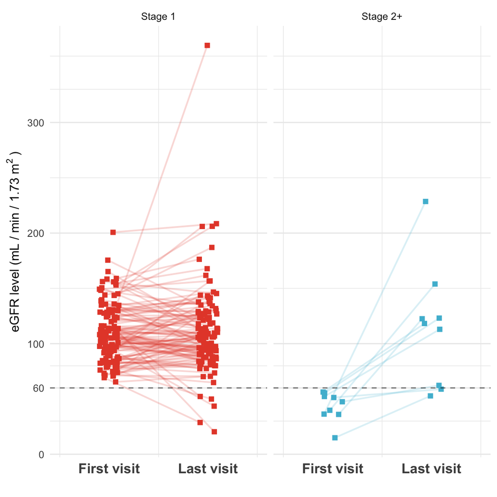

```r
prin4 %>%
  filter(subject_id %in% gfr_id) %>%
  filter(!is.na(gfr_class)) %>%
  arrange(subject_id,event_index) %>%
  group_by(subject_id) %>%
  filter(event_index==min(event_index)|event_index==max(event_index)) %>%
  mutate(first_visit = visit[event_index == min(event_index)],
         last_visit = visit[event_index==max(event_index)],
         egfr_visit = ifelse(event_index == min(event_index), 'First','Last'),
         black = ifelse(black==1, 'Black','Non-black')) %>%
  ungroup() %>%
  select(subject_id, black, first_visit, last_visit,
         egfr_visit,eGFR) %>%
  spread(egfr_visit, eGFR) %>%
  mutate(gfr_change = Last-First) %>%
  mutate(first_stage2 = ifelse(First <= 60, 'Stage 2+','Stage 1'))-> tmp1

tmp2 <- tmp1 %>% gather(visit, value, First, Last)
tmp2 <- tmp2 %>%
  mutate(visit = factor(paste(visit, 'visit'))) %>%
  mutate(x_pos = as.numeric(visit) + runif(nrow(.),-0.1, 0.1))


ggplot(tmp2, aes(x = x_pos, y = value, color = first_stage2))+
  geom_line(aes(group = subject_id), alpha = 0.2, size=0.7,
            show.legend = FALSE)+
  geom_point(shape=15, stroke=1,
             show.legend = FALSE) +
  geom_hline(yintercept = 60, linetype=2, alpha = 0.5) +
  facet_wrap(~first_stage2)+
  scale_x_continuous('', breaks = c(1,2), labels = c('First visit','Last visit')) +
  scale_y_continuous(bquote('eGFR level (mL / min / 1.73'~m^2~')'),
                     breaks = c(0,60,100, 200, 300))+
  coord_cartesian(xlim = c(0.5,2.5)) +
  labs(color = 'First visit stage') +
  theme_minimal() +
  theme(panel.grid.major.x = element_blank(),
        axis.text.x = element_text(face='bold', size=12))+
  ggsci::scale_color_npg()
```

### Remission

```r
prin4 %>% filter(subject_id %in% remission_id_mult) %>%
  group_by(subject_id) %>%
  mutate(gets_to_remission = ifelse(any(remission=='Yes', na.rm=T),1,0)) %>%
  filter(event_index == min(event_index)) %>%
  ungroup() %>%
  select(subject_id, event_index, gfr_class, gets_to_remission) %>%
  filter(!is.na(gfr_class)) %>%
  rename(Remission = gets_to_remission, `GFR class` = gfr_class) %>%
  mutate(Remission = ifelse(Remission==1, 'Yes','No')) %>%
  rename(`Ever in remission` = Remission) %>%
  tabyl(`Ever in remission`, `GFR class`) -> tab_gfr_remission

tab_gfr_remission %>%
  adorn_percentages('col') %>%
  adorn_pct_formatting() %>%
  adorn_ns() %>%
  adorn_title() %>%
  kable(caption = 'Chance of getting to remission by GFR class at LN diagnosis') %>%
  kable_styling()
```

Chance of getting to remission by GFR class at LN diagnosis

|  | GFR class |  |  |
| --- | --- | --- | --- |
| Ever in remission | Stage 1 | Stage 2 | Stage 3 |
| No | 65.8% (25) | 87.5% (7) | 100.0% (2) |
| Yes | 34.2% (13) | 12.5% (1) | 0.0% (0) |

A Fishers exact test gives a p-value of 0.4536257.

### Dialysis, transplant and ESRD

As we saw earlier, we don’t have sufficient information on these outcomes for this subset of subject who are LN-positive to assess how GFR stage at diagnosis is associated with them.

# Principle 6: Rituximab has been used as a steroid-sparing agent for induction in proliferative LN (LN vs no-LN, 3-4 vs 5)

Rituximab use: IMMMED = 30 MEDCATON = 30

### Rituximab use by nephritis class

```r
# Principle 6 -------------------------------------------------------------

raw_biopsy <- readRDS(here('data/rda/biopsy_classes1.rds')) # Updated for LN34+5 class
all_rows <- vroom(here('data/raw/all_rows_data_2020-01-31_1545.csv'))
ritux <- all_rows %>% filter(conceptValue=='Rituximab (Rituxan)') %>%
  clean_names() %>%
  select(subject_id, ritux = concept_value) %>%
  distinct()
## LN_classes was created in Principle 3
LN_classes <- readRDS(here('data/rda/LN_classes1.rds'))
tab_rtx_ln <- LN_classes  %>%
  left_join(ritux) %>%
  mutate(Rituximab = ifelse(is.na(ritux), 'No','Yes'),
         LN = ifelse(LN==0,'Neg', 'Pos')) %>%
  tabyl(Rituximab, LN)
tab_rtx_ln %>%
  adorn_percentages('col') %>%
  adorn_totals('row') %>%
  adorn_pct_formatting() %>%
  adorn_ns() %>%
  adorn_title() %>%
  knitr::kable(caption = 'Rituximab use between LN and non-LN subjects') %>%
  kable_styling()
```

Rituximab use between LN and non-LN subjects

|  | LN |  |
| --- | --- | --- |
| Rituximab | Neg | Pos |
| No | 88.0% (404) | 74.5% (161) |
| Yes | 12.0% (55) | 25.5% (55) |
| Total | 100.0% (459) | 100.0% (216) |

This is statistically significant, with the $\chi^2$ test p-value being $1.6 \times 10^{-5}$.

```r
tbl_rit_class <- LN_classes %>%
  left_join(ritux) %>%
  mutate(Rituximab = ifelse(is.na(ritux), 'No', 'Yes')) %>%
  filter(!is.na(LN)) %>%
  select(subject_id, LN34:LN50, Rituximab) %>%
  rename(`III/IV` = LN34,
         `III/IV + V` = LN345,
         `V only` = LN50) %>%
  gather(Class, value, `III/IV`:`V only`) %>%
  filter(value==1) %>%
  tabyl(Class, Rituximab)

tbl_rit_class %>%
  adorn_percentages('col') %>%
  adorn_totals() %>%
  adorn_pct_formatting() %>%
  adorn_ns() %>%
  adorn_title() %>%
  kable(caption = 'Rituximab use by LN class') %>%
  kable_styling()
```

Rituximab use by LN class

|  | Rituximab |  |
| --- | --- | --- |
| Class | No | Yes |
| III/IV | 72.9% (105) | 72.9% (35) |
| III/IV + V | 11.1% (16) | 12.5% (6) |
| V only | 16.0% (23) | 14.6% (7) |
| Total | 100.0% (144) | 100.0% (48) |

This is not statistically significant (p-value = 0.9488304)

### Is there differences in age/gender for people getting Rituximab

```r
demographic <- readRDS(here('data/rda/demographic.rds'))
bl <- demographic %>% left_join(slicc_info) %>%
  rename(ritux = slicc00) %>%
  mutate(ritux = ifelse(ritux==1, 'Yes','No'))

bl %>% group_by(ritux) %>%
  summarize(`Median age` = median(rheumage),
            IQR = IQR(rheumage)) %>%
  kable(caption = 'Rituximab use by age') %>%
  kable_styling()
```

Rituximab use by age

| ritux | Median age | IQR |
| --- | --- | --- |
| No | 14 | 4 |
| Yes | 14 | 3 |

This is not significant (Wilcoxon test p-value = 0.78)

```r
tab_rit_gender <- bl %>%
  rename(Sex=sex, Rituximab = ritux) %>%
  tabyl(Sex, Rituximab)
tab_rit_gender %>%
  adorn_percentages('col') %>%
  adorn_pct_formatting() %>%
  adorn_title('combined') %>%
  kable(caption = 'Rituximab use by gender') %>%
  kable_styling()
```

Rituximab use by gender

| Sex/Rituximab | No | Yes |
| --- | --- | --- |
| Female | 83.5% | 82.4% |
| Male | 16.5% | 17.6% |

This is not statistically significant ($\chi^2$ test p-value = 0.8)

### Differences in GFR by Rituximab use

We will look at LN+ patients and their GFR at time of diagnosis or at baseline, and compare the GFR levels for Rituximab users and non-users

```r
# prin4 is the dataset we will use, looking at the time of diagnosis,
# and then linking with Rituximab use

opts <- options(knitr.kable.NA='')
rtx_gfr <- prin4 %>% group_by(subject_id) %>%
  filter(event_index == min(event_index)) %>%
  ungroup() %>%
  left_join(ritux) %>%
  mutate(Rituximab = ifelse(is.na(ritux),'No','Yes'))
rtx_gfr %>%
  group_by(Rituximab) %>%
  summarize(N = sum(!is.na(eGFR)),
            Mean = mean(eGFR, na.rm=T),
            Median = median(eGFR, na.rm=T),
            SD = sd(eGFR, na.rm=T),
            IQR = IQR(eGFR, na.rm=T)) %>%
  mutate(`P-value` = c(wilcox.test(eGFR~Rituximab, data=rtx_gfr)$p.value, NA)) %>%
  kable(caption = 'GFR summaries by Rituximab use among LN patients;
        p-value based on Wilcoxon test',
        digits=2) %>%
  kable_styling(full_width = F)
```

GFR summaries by Rituximab use among LN patients; p-value based on Wilcoxon test

| Rituximab | N | Mean | Median | SD | IQR | P-value |
| --- | --- | --- | --- | --- | --- | --- |
| No | 123 | 113.97 | 105.41 | 124.39 | 35.91 | 0.56 |
| Yes | 46 | 104.73 | 106.66 | 34.37 | 44.54 |  |

```r
options(opts)
```

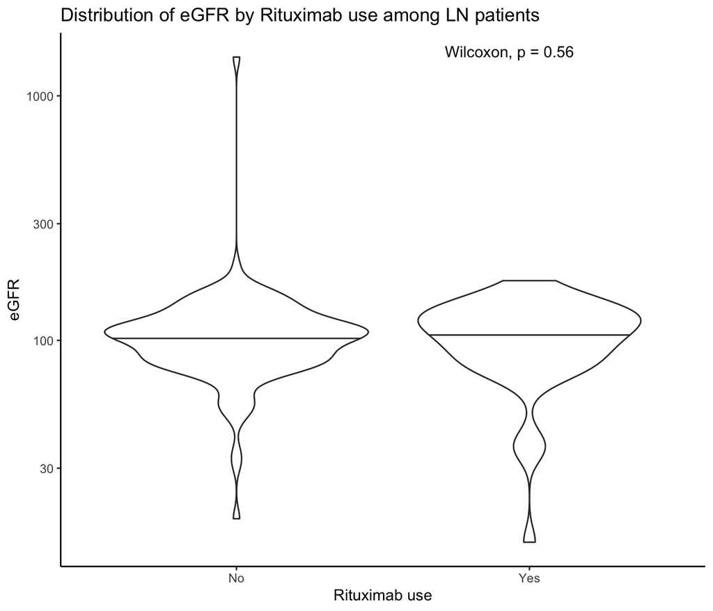

```r
ggplot(rtx_gfr, aes(x = Rituximab, y = eGFR))+
  geom_violin(draw_quantiles = 0.5)+
  ggpubr::stat_compare_means(method='wilcox.test',
                             label.x.npc = 0.8)+
  scale_y_log10() +
  theme_classic() +
  labs(x = 'Rituximab use', y = 'eGFR')+
  ggtitle('Distribution of eGFR by Rituximab use among LN patients')
```

### Rituximab and concurrent medications

```r
meds <- vroom(here('data/raw/meds_data_2020-01-31_1545.csv'),
              col_select = c(subjectId, MEDCATON)) %>%
  clean_names() %>%
  mutate(medication = str_to_title(medcaton)) %>%
  select(-medcaton)

blah <- LN_classes %>% left_join(ritux) %>% left_join(meds) %>%
  distinct()
blah1 <- blah %>% filter(!is.na(LN))

tab_rtx_med_overall <- blah %>%
  filter(medication != 'Rituximab (Rituxan)') %>%
  mutate(ritux = ifelse(is.na(ritux), 'No','Yes')) %>%
  tabyl(medication, ritux)
n_ritux_overall <- blah %>%
  select(subject_id, ritux) %>%
  distinct() %>%
  mutate(ritux = ifelse(is.na(ritux),'No','Yes')) %>%
  pull(ritux) %>%
  table()

library(glue)
tab_rtx_med_overall %>%
  mutate(perc_yes = Yes/n_ritux_overall['Yes']*100,
         perc_no = No/n_ritux_overall['No']*100,
         out_yes = glue("{round(perc_yes,2)}% ({Yes})"),
         out_no = glue("{round(perc_no,2)}% ({No})")) %>%
  slice_max(perc_yes, n = 10) %>%
  select(medication, out_no, out_yes) %>%
  set_names(c('Medication',glue('No Ritux (N = {n_ritux_overall["No"]})'),
              glue('With Ritux (N = {n_ritux_overall["Yes"]})'))) %>%
  kable(caption = 'Top 10 drugs among RTX users and
        corresponding proportions among non-RTX patients') %>%
  kable_styling()
```

Top 10 drugs among RTX users and corresponding proportions among non-RTX patients

| Medication | No Ritux (N = 565) | With Ritux (N = 110) |
| --- | --- | --- |
| Hydroxychloroquine (Plaquenil) | 93.81% (530) | 94.55% (104) |
| Mycophenolate Mofetil (Cellcept) | 46.9% (265) | 70.91% (78) |
| Cyclophosphamide (Cytoxan) | 6.9% (39) | 41.82% (46) |
| Azathioprine (Imuran) | 15.93% (90) | 20.91% (23) |
| Aspirin (Asa) | 5.31% (30) | 17.27% (19) |
| Immune Globulin (Ivig) | 1.42% (8) | 12.73% (14) |
| Methotrexate | 18.58% (105) | 12.73% (14) |
| Mycophenolic Acid (Mpa, Myfortic) | 5.13% (29) | 10.91% (12) |
| Lisinopril | 2.65% (15) | 10% (11) |
| Vitamin D | 21.42% (121) | 10% (11) |

```r
tab_rtx_med <- blah1 %>%
  filter(medication != 'Rituximab (Rituxan)') %>%
  mutate(ritux = ifelse(is.na(ritux), 'No','Yes')) %>%
  tabyl(medication, ritux)
o <- order(tab_rtx_med$Yes)

n_ritux <- blah1 %>%
  select(subject_id, ritux) %>%
  distinct() %>%
  mutate(ritux = ifelse(is.na(ritux),'No','Yes')) %>%
  pull(ritux) %>%
  table()

library(glue)
tab_rtx_med %>%
  mutate(perc_yes = Yes/n_ritux['Yes']*100,
         perc_no = No/n_ritux['No']*100,
         out_yes = glue("{round(perc_yes,2)}% ({Yes})"),
         out_no = glue("{round(perc_no,2)}% ({No})")) %>%
  slice_max(perc_yes, n = 10) %>%
  select(medication, out_no, out_yes) %>%
  set_names(c('Medication',glue('No Ritux (N = {n_ritux["No"]})'),
              glue('With Ritux (N = {n_ritux["Yes"]})'))) %>%
  kable(caption = 'Top 10 drugs used by LN patients\n among RTX users and
        corresponding proportions among non-RTX patients') %>%
  kable_styling()
```

| Medication | No Ritux (N = 565) | With Ritux (N = 110) |
| --- | --- | --- |
| Hydroxychloroquine (Plaquenil) | 93.81% (530) | 94.55% (104) |
| Mycophenolate Mofetil (Cellcept) | 46.9% (265) | 70.91% (78) |
| Cyclophosphamide (Cytoxan) | 6.9% (39) | 41.82% (46) |
| Azathioprine (Imuran) | 15.93% (90) | 20.91% (23) |
| Aspirin (Asa) | 5.31% (30) | 17.27% (19) |
| Immune Globulin (Ivig) | 1.42% (8) | 12.73% (14) |
| Methotrexate | 18.58% (105) | 12.73% (14) |
| Mycophenolic Acid (Mpa, Myfortic) | 5.13% (29) | 10.91% (12) |
| Lisinopril | 2.65% (15) | 10% (11) |
| Vitamin D | 21.42% (121) | 10% (11) |

```r
# out_rtx_med <- tab_rtx_med %>%
#   adorn_percentages('col') %>%
#   adorn_pct_formatting() %>%
#   adorn_ns() %>%
#   slice(rev(o))
#
# tab_rtx_med %>%
#   adorn_percentages('col') %>%
#   adorn_pct_formatting() %>%
#   adorn_ns() %>%
#   slice(rev(o)) %>%
#   slice(1:10) %>%
#   kable(caption = 'Top 10 drugs among RTX users and
#         corresponding proportions among non-RTX patients') %>%
#   kable_styling()


d1 <- tab_rtx_med  %>%
  mutate(perc_yes = Yes/n_ritux['Yes']*100,
         perc_no = No/n_ritux['No']*100) %>%
  mutate(pct_diff = perc_yes - perc_no) %>%
  mutate(pval = map2_dbl(No, Yes, ~prop.test(c(.x, .y), unclass(n_ritux))$p.value))



# tab_rtx_med  %>%
#   mutate(perc_yes = Yes/n_ritux['Yes']*100,
#          perc_no = No/n_ritux['No']*100) %>%
#     mutate(pct_diff = perc_yes - perc_no) %>%
#   slice_max(abs(pct_diff), n=10) %>%
d1 %>%
  slice_min(pval, n=10) %>%
  rename(Difference = pct_diff) %>%
  # select(medication, perc_no, perc_yes, Difference) %>%
  mutate(across(perc_yes:Difference, ~paste0(round(.x,2),'%'))) %>%
  mutate(perc_no = glue("{perc_no} ({No})"),
         perc_yes = glue('{perc_yes} ({Yes})'),
         pval = format.pval(pval, digits=3)) %>%
  select(medication, perc_no, perc_yes, Difference, pval) %>%
  kable(caption = 'Top 10 drugs among LN patients in difference of usage between RTX and non-RTX',
        col.names = c('Medication',glue('No Ritux (N = {n_ritux["No"]})'),
                      glue('With Ritux (N = {n_ritux["Yes"]})'),
                      'Difference', 'P-value')) %>%
  kable_styling()
```

| Medication | No Ritux (N = 565) | With Ritux (N = 110) | Difference | P-value |
| --- | --- | --- | --- | --- |
| Cyclophosphamide (Cytoxan) | 6.9% (39) | 41.82% (46) | 34.92% | < 2e-16 |
| Immune Globulin (Ivig) | 1.42% (8) | 12.73% (14) | 11.31% | 5.92e-09 |
| Mycophenolate Mofetil (Cellcept) | 46.9% (265) | 70.91% (78) | 24.01% | 6.69e-06 |
| Aspirin (Asa) | 5.31% (30) | 17.27% (19) | 11.96% | 2.41e-05 |
| Lisinopril | 2.65% (15) | 10% (11) | 7.35% | 0.000695 |
| Bactrim | 0% (0) | 2.73% (3) | 2.73% | 0.001628 |
| Enoxaparin | 0% (0) | 2.73% (3) | 2.73% | 0.001628 |
| Vitamin D | 21.42% (121) | 10% (11) | -11.42% | 0.008527 |
| Tacrolimus Oral (Prograf) | 1.24% (7) | 5.45% (6) | 4.22% | 0.010343 |
| Famotidine | 0.88% (5) | 4.55% (5) | 3.66% | 0.013284 |

```r
# openxlsx::write.xlsx(list('Medications' = out_rtx_med,
#                           'Differences' = out_rtx_med_diff),
#                     file = here('data/raw/rtx_meds.xlsx'))
```

```r
# Session info ------------------------------------------------------------
```

# Session information

This analysis was done using R version 3.6.3 (2020-02-29) and the following packages

data.table (1.12.8); dplyr (1.0.2); forcats (0.5.0); fs (1.5.0); ggplot2 (3.3.2); glue (1.4.1.9000); here (0.1); janitor (2.0.1); kableExtra (1.1.0); knitr (1.29); pacman (0.5.1); purrr (0.3.4); readr (1.3.1); readxl (1.3.1); stringr (1.4.0); tibble (3.0.3); tidyr (1.1.2); tidyverse (1.3.0); vroom (1.2.1)